# Análisis exploratorio del protocolo de temperatura del aire de GLOBE-NASA

Gustavo Alberto Amador Fonseca (Escuela de Matemática, Universidad de Costa Rica (UCR) - Asistente del Centro de Investigación en Matemática Pura y Aplicada (CIMPA))  
2024-10-26

```r
# Cargando una librería para utilizar funciones específicas
library(leaflet)
library(dplyr)
library(ggplot2)
library(readr)
library(corrplot)
library(hms)

data_ori <- read_csv("C:/Users/AMADOR/OneDrive - Universidad de Costa Rica/ASISTENCIA/Fabio Sánchez/Climate_Project/Gustavo/data/Air_temperature/GLOBEMeasurementData-22014.csv")
#View(data_ori)
```

# Data

El conjunto de datos corresponde a las mediciones recopiladas a través del programa GLOBE, el cual permite la participación de diferentes escuelas y organizaciones desde 1996. Este enfoque de participación ciudadana busca promover la observación del ambiente a través del registro de datos sobre condiciones climáticas y variables ambientales, tales como la temperatura del aire y la elevación de los sitios de medición. En este caso, se ha tomado una muestra que considera exclusivamente las observaciones provenientes de Costa Rica y Panamá, lo cual permite un enfoque más local.

Un aspecto importante de estos datos es la inclusión de mediciones realizadas por miembros de la comunidad, lo cual permite una cobertura amplia de la recolección de datos en diferentes lugares. Sin embargo, los datos deben ser cuidadosamente validados, ya que la precisión puede variar considerablemente dependiendo del tipo de equipo utilizado y la experiencia de los participantes. Además, la calidad de algunos campos como comments o globe teams no está completamente documentada, lo que podría dificultar algunos tipos de análisis.

## Variables

| Variable | Units/Format | Definition |
| --- | --- | --- |
| `organization_id` | text | Identificador de la organización participante en el programa GLOBE. |
| `org_name` | text | Nombre de la organización participante en el programa GLOBE. |
| `site_id` | text | Identificador del sitio donde se realizó la medición. |
| `site_name` | text | Nombre del sitio donde se realizó la medición. |
| `latitude` | decimal degrees north | Latitud registrada por GPS en el lugar de la medición. |
| `longitude` | decimal degrees east | Longitud registrada por GPS en el lugar de la medición. |
| `elevation` | meters above sea level | Elevación del sitio donde se realizaron las mediciones. |
| `measured_on` | Date (YYYY-MM-DD) | Fecha en la que se realizaron las mediciones. |
| `air temps:userid` | numeric ID | Identificador del usuario que realizó la medición de la temperatura del aire. |
| `air temps:measured at` | DateTime (YYYY-MM-DD HH:MM:SS) | Fecha y hora exacta en la que se realizó la medición del aire. |
| `air temps:solar measured at` | DateTime (YYYY-MM-DD HH:MM:SS) | Fecha y hora exacta de la medición solar. |
| `air temps:current temp (deg C)` | degrees Celsius | Temperatura actual medida en grados Celsius. |
| `air temps:comments` | text | Comentarios sobre las mediciones de temperatura del aire. |
| `air temps:globe teams` | text | Equipos participantes en el programa GLOBE que realizaron las mediciones. |

Estas variables permiten realizar un análisis espacial y temporal de las condiciones climáticas en los sitios seleccionados, lo cual es de gran utilidad para estudios ambientales que requieran correlacionar variables geográficas con los patrones de temperatura observados.

# Proceso de Limpieza de Datos

1. **Eliminación de la primera observación**: Se eliminó la primera observación del conjunto de datos, ya que no aportaba información relevante.
2. **Renombrado de columnas**: Se cambiaron los nombres de algunas columnas para hacerlas más fáciles de manejar, por ejemplo, `air temps:userid` se renombró a `userid`.
3. **Eliminación de columnas no relevantes**: Se eliminaron las columnas `air temps:comments`, `air temps:globe teams`, entre otras, ya que no aportaban información útil para el análisis.
4. **Conversión de columnas a tipo numérico**: Las columnas `latitude`, `longitude` y `elevation` se convirtieron a formato numérico para facilitar el análisis.
5. **Separación de columnas de fecha y hora**: Las columnas que contenían fecha y hora juntas (`measured_at` y `solar_measured_at`) fueron separadas en columnas independientes de fecha y hora para un análisis más detallado.

```r
# Elimiinar primer observación que no sirve
data_clea <- data_ori[-1, ]

#Cambiar nombre de columnas
data_clea <- data_clea %>% rename("userid" = "air temps:userid", "measured_at" = "air temps:measured at","solar_measured_at" = "air temps:solar measured at", "current_temp_C" = "air temps:current temp (deg C)")

# Eliminar columnas que no aportan información
data_clea <- data_clea %>% select(- "air temps:comments", -"air temps:globe teams")

# Convertir a numericas las columnas que lo deben ser
cols_numericas <- c("latitude", "longitude", "elevation")  # Especifica los nombres de las columnas
data_clea[cols_numericas] <- lapply(data_clea[cols_numericas], as.numeric)

# Separar columnas que tiene fecha y hora juntas
data_clea$fecha_measured_at <- as.Date(data_clea$`measured_at`) # Crear columna de fecha
data_clea$`hora_measured_at` <- format(data_clea$`measured_at`, format = "%H:%M:%S") # Crear columna de hora

data_clea$`fecha_solar_measured_at` <- as.Date(data_clea$`solar_measured_at`) # Crear columna de fecha
data_clea$`hora_solar_measured_at` <- format(data_clea$`solar_measured_at`, format = "%H:%M:%S") # Crear columna de hora


#head(data_clea)
#View(data_clea)
```

# Análisis exploratorio de variables

## Ubicación geográfica de la toma de datos

Visualizar la distribución espacial de los puntos de recolección de datos y explorar su ubicación geográfica de una manera interactiva.

```r
# Hacer las columnas de longitud y latitud son numéricas
data_ori$longitude <- as.numeric(data_ori$longitude)
data_ori$latitude <- as.numeric(data_ori$latitude)

# Crear un mapa interactivo
leaflet(data_ori) %>%
  addTiles() %>%  # Mapa base
  addCircles(
    lng = ~longitude,
    lat = ~latitude,
    color = "blue",  # Color de los círculos
    radius = 50,  # Ajusta el tamaño del círculo según sea necesario
    fillOpacity = 0.5,
    stroke = FALSE
  ) %>%
  addLegend("bottomright",
            pal = colorNumeric(palette = "blue", domain = data_ori$longitude),
            values = data_clea$longitude,
            title = "Puntos")
```

[interactive chart not shown]

## Historgrama de la variable Elevación `elevation`

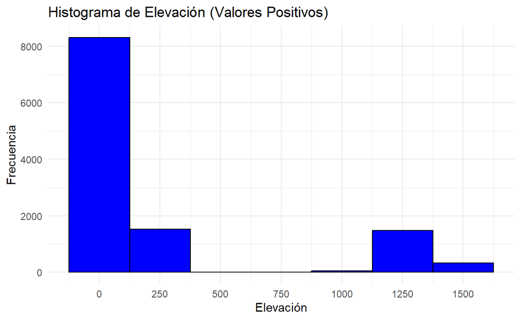

```r
# Filtrar datos para que solo incluya elevaciones mayores que 0
data_filtered <- data_clea[as.numeric(data_clea$elevation) > 0, ]

# Crear un histograma usando ggplot con ancho de barra de 250
ggplot(data_filtered, aes(x = elevation)) +
  geom_histogram(binwidth = 250, fill = "blue", color = "black") +  # Ancho de barra ajustado a 500
  labs(title = "Histograma de Elevación (Valores Positivos)",
       x = "Elevación",
       y = "Frecuencia") +
  scale_x_continuous(breaks = seq(0, max(data_filtered$elevation, na.rm = TRUE), by = 250)) +  # Establecer los breaks en el eje x
  theme_minimal()  # Estilo minimalista
```

La distribución del histograma muestra una gran concentración de mediciones de elevación cerca de cero, con una gran cantidad de valores menores a 250 metros sobre el nivel del mar. Esto podría indicar la presencia de datos erróneos o problemas de calidad en la recolección de las elevaciones, especialmente considerando que algunas de las ubicaciones donde se tomaron las muestras no deberían tener elevaciones tan bajas o negativas. Además, existe una agrupación más pequeña de valores alrededor de 1250 metros, lo cual sugiere una posible segmentación en la muestra que podría deberse a diferentes tipos de terreno o zonas geográficas.

## Histograma de la variable temperatura del aire (grados Celsius) `current_temp_C`

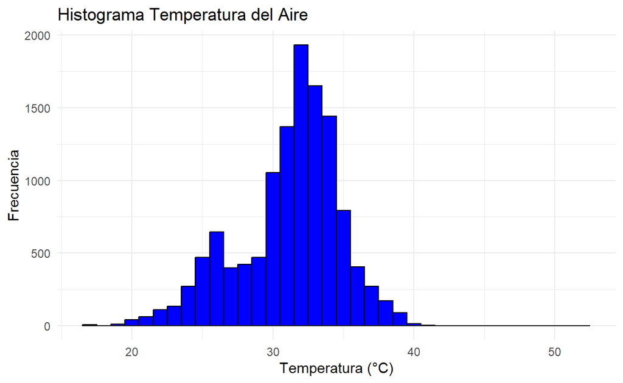

```r
# Convertir la columna a numérica si es necesario
data_clea$current_temp_C <- as.numeric(as.character(data_clea$current_temp_C))

# Crear el histograma con ancho de barra de 1
ggplot(data_clea, aes(x = current_temp_C)) +
  geom_histogram(binwidth = 1, fill = "blue", color = "black") +  # Ancho de barra ajustado a 1
  labs(title = "Histograma Temperatura del Aire",
       x = "Temperatura (°C)",
       y = "Frecuencia") +
  theme_minimal()  # Estilo minimalista
```

## Historgrama de la variable hora de la medición solar `hora_solar_measured_at`

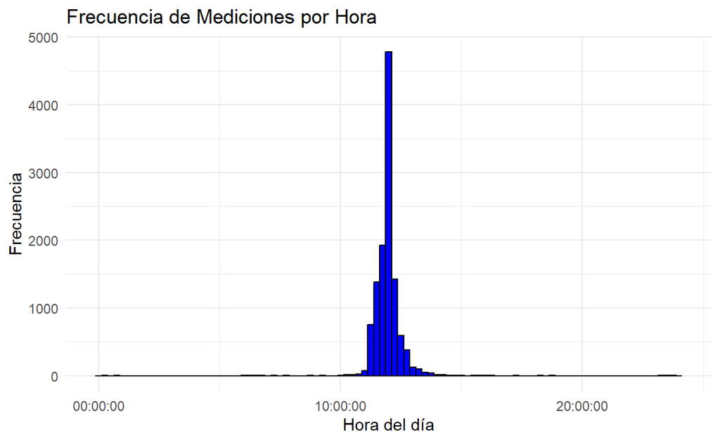

```r
# Cambiar formato de la varibale hora, a uno adecuado para graficar
data_clea$hora_solar_measured_at <- hms::as_hms(data_clea$hora_solar_measured_at)

ggplot(data_clea, aes(x = hora_solar_measured_at)) +
  geom_histogram(binwidth = 15*60, fill = "blue", color = "black") +  # Ancho de barra de 1 hora
  labs(title = "Frecuencia de Mediciones por Hora",
       x = "Hora del día",
       y = "Frecuencia") +
  theme_minimal()
```

## Historgrama de la variable fecha de medicion `fecha_measured_at`

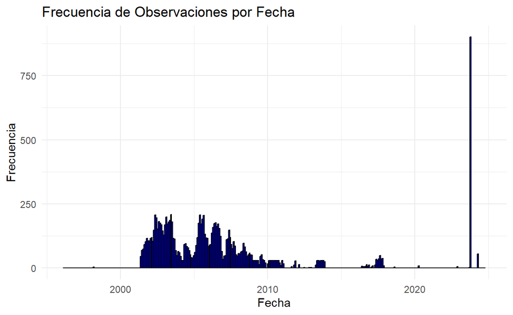

```r
# Graficar la frecuencia de observaciones por fecha
ggplot(data_clea, aes(x = fecha_measured_at)) +
  geom_histogram(binwidth = 30, fill = "blue", color = "black") +  # Cada barra representa 1 día
  labs(title = "Frecuencia de Observaciones por Fecha",
       x = "Fecha",
       y = "Frecuencia") +
  theme_minimal()
```

Para graficar el historgrama se tomaron intervalos de 30 días,para poder observar la densidad de la toma de datos.

1. **Concentración antes de 2010**: Alta frecuencia de observaciones, posiblemente por una campaña específica.
2. **Disminución después de 2010**: Reducción drástica de datos, indicando menor actividad o cambios en el proyecto.
3. **Pico en 2023**: Un gran aumento reciente de observaciones, que sería una carga masiva de datos.

# Matriz de correlación entre las variables `elevation`, `latitude`, `longitude`, `current_temp_C`, `hora_solar_decimal`

```r
# Convertir las variables hora a formato hms
data_clea$hora_solar_measured_at <- hms::as_hms(data_clea$solar_measured_at)

# Convertir la variable hora a decimales
data_clea$hora_solar_decimal <- as.numeric(data_clea$hora_solar_measured_at) / 3600

# Seleccionar las columnas para la matriz de correlación, sin incluir `hora_measured_decimal`
cor_data <- data_clea[, c("elevation", "latitude", "longitude", "current_temp_C", "hora_solar_decimal")]

# La matriz de correlación
cor_matrix <- cor(cor_data, use = "complete.obs")
```

|  | elevation | latitude | longitude | current_temp_C | hora_solar_decimal |
| --- | --- | --- | --- | --- | --- |
| **elevation** | 1.00000000 | 0.47949065 | -0.48547958 | -0.52955432 | 0.06505916 |
| **latitude** | 0.47949065 | 1.00000000 | -0.78040997 | -0.34113489 | 0.06580582 |
| **longitude** | -0.48547958 | -0.78040997 | 1.00000000 | 0.06611810 | -0.02821455 |
| **current_temp_C** | -0.52955432 | -0.34113489 | 0.06611810 | 1.00000000 | -0.07034716 |
| **hora_solar_decimal** | 0.06505916 | 0.06580582 | -0.02821455 | -0.07034716 | 1.00000000 |

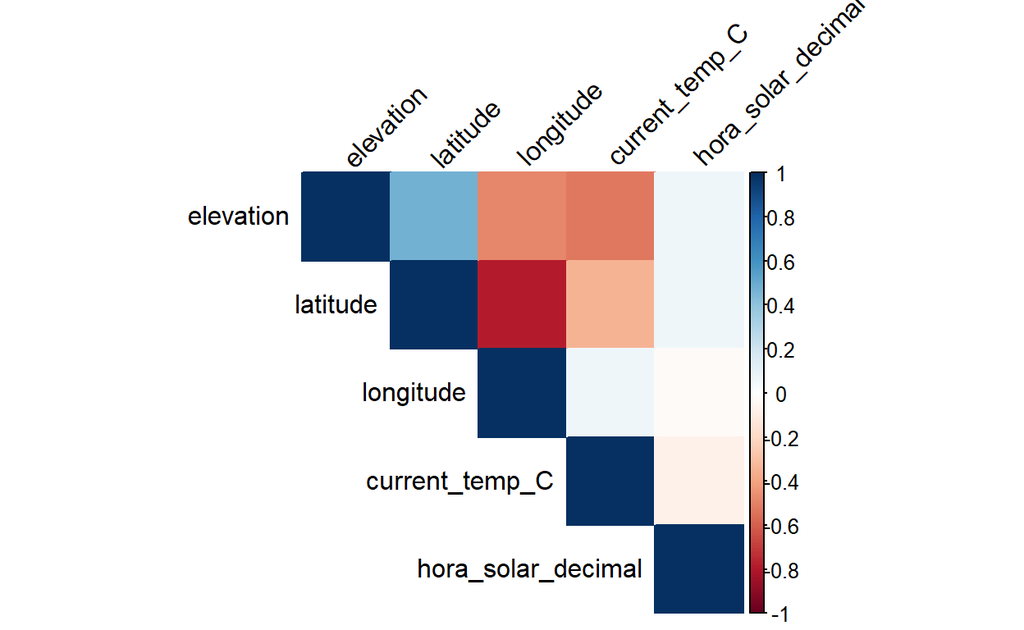

```r
# Visualizar la matriz de correlación
corrplot(cor_matrix, method = "color", type = "upper", tl.col = "black", tl.srt = 45)
```

## Observaciones sobre la Matriz de Correlación

La matriz de correlación, junto con el mapa de calor generado, muestra la relación entre diferentes variables ambientales recopiladas en el conjunto de datos. Algunas observaciones destacadas son:

1. **Correlación Elevación y Latitude**: Existe una correlación moderada positiva (0.48) entre la elevación y la latitud. Esto indica que a medida que la latitud aumenta, la elevación también tiende a incrementarse, lo cual puede estar relacionado con las características geográficas de la región estudiada.
2. **Correlación Elevación y Temperatura Actual**: Hay una correlación negativa moderada (-0.53) entre la elevación y la temperatura del aire. Esto sugiere que a mayores elevaciones, la temperatura tiende a ser menor, lo cual es consistente con el comportamiento climático general, donde a mayores altitudes se observan temperaturas más bajas.
3. **Correlación Latitude y Longitude**: Se observa una correlación negativa fuerte (-0.78) entre la latitud y la longitud, lo cual podría reflejar la distribución específica de los puntos de medición en Costa Rica y Panamá.
4. **Temperatura Actual y Hora Solar Decimal**: Existe una correlación leve negativa (-0.07) entre la temperatura actual y la hora solar decimal. Esta relación sugiere que, aunque hay una variación en la temperatura a lo largo del día, el impacto es relativamente débil en el conjunto de datos analizado.
5. **Correlación Latitude y Hora Solar Decimal**: La correlación entre la latitud y la hora solar decimal es muy baja (0.07), indicando que no existe una relación lineal significativa entre estas variables en el contexto de este conjunto de datos.

En general, estas correlaciones nos permiten entender mejor las relaciones entre las variables ambientales, como la influencia de la elevación y la latitud sobre la temperatura. Sin embargo, es importante tener en cuenta que la correlación no implica causalidad, y otros factores podrían estar influyendo en estas relaciones.